# SciPy

Informatik II für Geodäsie (522.408, 522.409)  
Informatik 2 (GST.412UF, GST.413UF)

**Sebastian Strasser**

Institut für Geodäsie

6. Juni 2019

```python
# interactive plots in Jupyter notebook
%matplotlib notebook
```

## Ziele

Ziel dieser Einheit ist es

- zu lernen, welche Möglichkeiten SciPy in der wissenschaftlichen Programmierung bietet
- beispielhaft häufig verwendete Algorithmen kennenzulernen

[SciPy](https://scipy.org) ist eine Sammlung von mathematischen Algorithmen und Komfortfunktionen, die auf [NumPy](http://www.numpy.org) aufbauen.

SciPy ist in Unterpakete organisiert, die verschiedene wissenschaftliche Bereiche abdecken. Einige Beispiele:

- `constants`: Physikalische und mathematische Konstanten
- `fftpack`: Fast-Fourier-Transformationen
- `integrate`: Integration und Löser für gewöhnliche Differentialgleichungen
- `interpolate`: Interpolation und Splines
- `linalg`: Lineare Algebra
- `signal`: Signalverarbeitung
- `spatial`: Räumliche Datenstrukturen und Algorithmen
- `stats`: Statistische Verteilungen und Funktionen

Da SciPy auf NumPy aufbaut, können für die grundlegende Verwaltung von Arrays NumPy-Befehle verwendet werden:

```python
import numpy as np
np.zeros(3)
```

```
array([0., 0., 0.])
```

SciPy-Funktionen können durch Importieren des jeweiligen Untermoduls verwendet werden:

```python
from scipy import signal
signal.detrend([1, 2, 1])
```

```
array([-0.33333333,  0.66666667, -0.33333333])
```

Beschreibungen zu allen Funktionen gibt es in der [SciPy-Dokumentation](https://docs.scipy.org/doc/scipy/reference/index.html) oder mittels `help`-Befehl:

```python
help(signal.detrend)
```

```
Help on function detrend in module scipy.signal.signaltools:

detrend(data, axis=-1, type='linear', bp=0)
    Remove linear trend along axis from data.

    Parameters
    ----------
    data : array_like
        The input data.
    axis : int, optional
        The axis along which to detrend the data. By default this is the
        last axis (-1).
    type : {'linear', 'constant'}, optional
        The type of detrending. If ``type == 'linear'`` (default),
        the result of a linear least-squares fit to `data` is subtracted
        from `data`.
        If ``type == 'constant'``, only the mean of `data` is subtracted.
    bp : array_like of ints, optional
        A sequence of break points. If given, an individual linear fit is
        performed for each part of `data` between two break points.
        Break points are specified as indices into `data`.

    Returns
    -------
    ret : ndarray
        The detrended input data.

    Examples
    --------
    >>> from scipy import signal
    >>> randgen = np.random.RandomState(9)
    >>> npoints = 1000
    >>> noise = randgen.randn(npoints)
    >>> x = 3 + 2*np.linspace(0, 1, npoints) + noise
    >>> (signal.detrend(x) - noise).max() < 0.01
    True
```

## Lineare Algebra ([scipy.linalg](https://docs.scipy.org/doc/scipy/reference/tutorial/linalg.html))

SciPy bietet sehr schnelle/effiziente Rechenmethoden für lineare Algebra. `scipy.linalg` enthält alle Funktionen von `numpy.linalg` und einige weitere für fortgeschrittene Anwendungen. Je nach Art der NumPy-Installation kann es sein, dass die SciPy-Varianten schneller sind.

### Grundlegende Funktionen

Inverse einer Matrix mit `inv`:

```python
import numpy as np
from scipy import linalg

A = np.array([[1, 3, 5], [2, 5, 1], [2, 3, 8]])
linalg.inv(A)
```

```
array([[-1.48,  0.36,  0.88],
       [ 0.56,  0.08, -0.36],
       [ 0.16, -0.12,  0.04]])
```

Lineare Gleichungssysteme Lösen mit `solve`:

$$ \begin{split} x& + 3y& \;+\; 5&z = 10 \\ 2x& + 5y& \;+\; &z = 8 \\ 2x& + 3y& \;+\; 8&z = 3 \end{split} $$

```python
import numpy as np
from scipy import linalg

A = np.array([[1, 3, 5], [2, 5, 1], [2, 3, 8]])
b = np.array([10, 8, 3])

linalg.solve(A, b)
```

```
array([-9.28,  5.16,  0.76])
```

Determinante bestimmen mit `det`:

```python
import numpy as np
from scipy import linalg

A = np.array([[1, 3, 5], [2, 5, 1], [2, 3, 8]])
linalg.det(A)
```

```
-25.000000000000004
```

Norm berechnen mit `norm`:

```python
import numpy as np
from scipy import linalg

A = np.array([[1, 2], [3, 4]])
print(linalg.norm(A))         # Frobenius norm (default)
print(linalg.norm(A, 1))      # L1 norm (max column sum)
print(linalg.norm(A, np.inf)) # L inf norm (max row sum)
```

```
5.477225575051661
6.0
7.0
```

### Dekompositionen

Eigenwerte und Eigenvektoren mit `eig`:

$$ \mathbf{A}\mathbf{v} = \lambda \mathbf{v} $$

```python
import numpy as np
from scipy import linalg

A = np.array([[1, 2], [3, 4]])
eigenValues, eigenVectors = linalg.eig(A)
print(eigenValues)
print(eigenVectors) # one column per eigen vector
```

```
[-0.37228132+0.j  5.37228132+0.j]
[[-0.82456484 -0.41597356]
 [ 0.56576746 -0.90937671]]
```

Singulärwertzerlegung (*Singular value decomposition*) mit `svd` und `diagsvd`:

$$ \mathbf{A} = \mathbf{U \Sigma V}^H $$

```python
import numpy as np
from scipy import linalg

A = np.array([[1, 2, 3], [4, 5, 6]])
M, N = A.shape
U, s, Vh = linalg.svd(A)
Sig = linalg.diagsvd(s, M, N)

print(U)
print(Sig)
print(Vh)

U@Sig@Vh
```

```
[[-0.3863177  -0.92236578]
 [-0.92236578  0.3863177 ]]
[[9.508032   0.         0.        ]
 [0.         0.77286964 0.        ]]
[[-0.42866713 -0.56630692 -0.7039467 ]
 [ 0.80596391  0.11238241 -0.58119908]
 [ 0.40824829 -0.81649658  0.40824829]]
```

```
array([[1., 2., 3.],
       [4., 5., 6.]])
```

## Integration ([scipy.integrate](https://docs.scipy.org/doc/scipy/reference/tutorial/integrate.html))

Dieses Unterpaket stellt verschiedene Integrationstechniken zur Verfügung, unter anderem einen Integrator für gewöhnliche Differentialgleichungen.

### Allgemeine Integration

Allgemeine Integration erfolgt mit der Funktion quad:

```
quad(integrand, lowerLimit, upperLimit, args=(arguments))
```

Beispiel: Lösen des folgenden Integrals

$$ I(a,b) = \int_0^1 a x^2 + b \; dx $$

```python
from scipy.integrate import quad

def integrand(x, a, b):
    return a * x**2 + b

a, b = 2, 1
I, abserr = quad(integrand, 0, 1, args=(a, b))
print(I)
```

```
1.6666666666666667
```

### Trapezregel

Integration entlang einer Achse mittels Trapezregel:

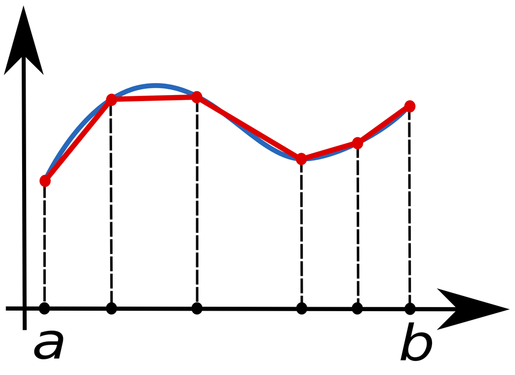

```python
import numpy as np # or scipy.integrate.trapz

np.trapz([1, 2, 3])
```

```
4.0
```

```python
np.trapz([1, 2, 3], x=[4, 6, 8])
```

```
8.0
```

### Anfangswertprobleme

Lösen eines Anfangswertproblems (*Initial value problem*) mit der Funktion solve_ivp:

```
solve_ivp(function, integrationInterval, initialState)
```

Beispiel: Exponentieller Verfall

$$ \frac{dy}{dt} = -0.5 \; y $$

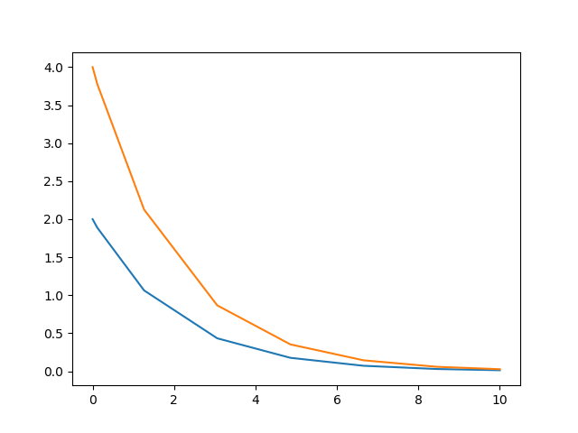

```python
from scipy.integrate import solve_ivp
import matplotlib.pyplot as plt

def exponential_decay(t, y):
    return -0.5 * y

sol = solve_ivp(exponential_decay, [0, 10], [2, 4])
fig = plt.figure()
plt.plot(sol.t, sol.y[0])
plt.plot(sol.t, sol.y[1]);
```

## Ableitung

Natürlich können mit SciPy auch Funktionen abgeleitet werden:

Beispiel: Zweite Ableitung von $f(x) = x^3 + ax^2$

```python
from scipy.misc import derivative

def f(x, a):
    return x**3 + a*x**2

derivative(f, 1, n=2, args=(5,)) # x0 = 1, a = 5
```

```
16.0
```

## Interpolation ([scipy.interpolate](https://docs.scipy.org/doc/scipy/reference/tutorial/interpolate.html))

### Eindimensionale Interpolation

Eindimensionale Interpolation erfolgt mit der Funktion interp1d:

```
f = interp1d(x, y, kind)
```

$x$ und $y$ sind Werte, die eine Funktion $f$ via $y = f(x)$ approximieren.

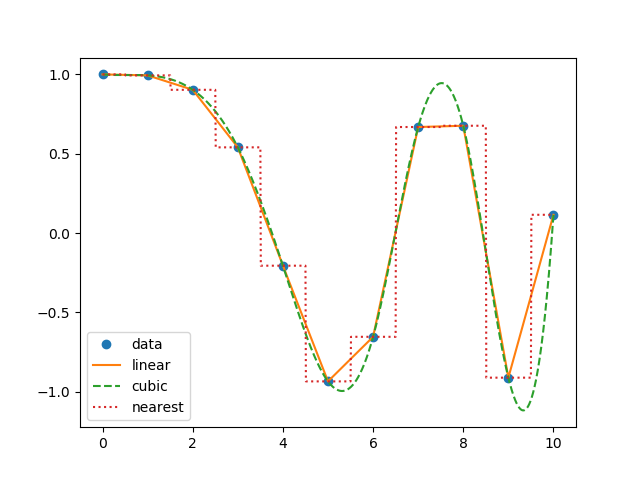

```python
from scipy.interpolate import interp1d
import matplotlib.pyplot as plt

x = np.linspace(0, 10, num=11, endpoint=True)
y = np.cos(-x**2/9.0)
f_linear  = interp1d(x, y)
f_cubic   = interp1d(x, y, kind='cubic')
f_nearest = interp1d(x, y, kind='nearest')

fig = plt.figure()
xnew = np.linspace(0, 10, num=1001, endpoint=True)
plt.plot(x, y, 'o', xnew, f_linear(xnew), '-', xnew, f_cubic(xnew), '--', xnew, f_nearest(xnew), ':')
plt.legend(['data', 'linear', 'cubic', 'nearest'], loc='best');
```

### Mehrdimensionale Interpolation

Mit der Funktion griddata können unstrukturierte, mehrdimensionale Daten interpoliert werden.

```
interpolationValues = griddata(dataPoints, dataValues,
                               interpolationPoints, method)
```

Beispiel: 1000 bekannte Punkte der zweidimensionalen Funktion

$$ f(x,y) = x \;(1-x) \;\cos(4 \pi x) \;\sin^2 (4 \pi y^2) $$

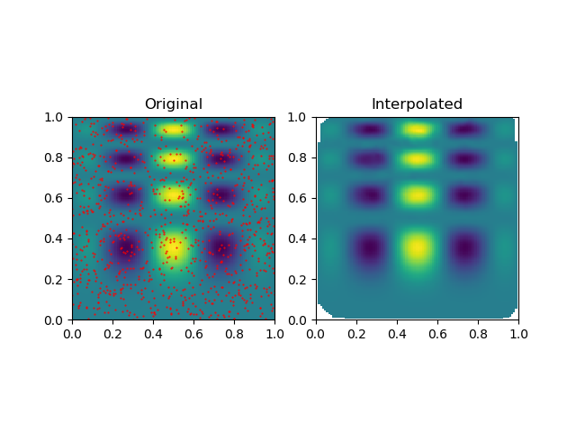

```python
import numpy as np
from scipy.interpolate import griddata
import matplotlib.pyplot as plt

def func(x, y):
    return x*(1-x)*np.cos(4*np.pi*x) * np.sin(4*np.pi*y**2)**2

grid_x, grid_y = np.mgrid[0:1:100j, 0:1:200j]
points = np.random.rand(1000, 2)
values = func(points[:,0], points[:,1])

grid_z = griddata(points, values, (grid_x, grid_y), method='cubic')

fig = plt.figure()
plt.subplot(121)
plt.imshow(func(grid_x, grid_y).T, extent=(0,1,0,1), origin='lower')
plt.plot(points[:,0], points[:,1], 'r.', ms=1)
plt.title('Original')
plt.subplot(122)
plt.imshow(grid_z.T, extent=(0,1,0,1), origin='lower')
plt.title('Interpolated');
```

## Räumliche Algorithmen ([scipy.spatial](https://docs.scipy.org/doc/scipy/reference/tutorial/spatial.html))

Delaunay-Triangulation (Dreiecke aus Punkten)

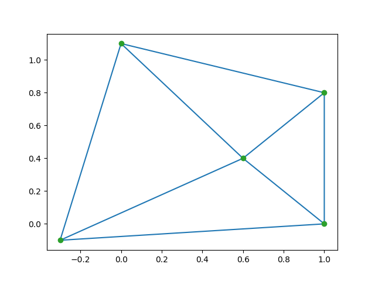

```python
from scipy.spatial import Delaunay
import matplotlib.pyplot as plt

points = np.array([[-0.3, -0.1], [0, 1.1], [1, 0], [1, 0.8], [0.6, 0.4]])
triangles = Delaunay(points)

fig = plt.figure()
plt.triplot(points[:,0], points[:,1], triangles.simplices)
plt.plot(points[:,0], points[:,1], 'o');
```

Konvexe Hülle (Umschließende Hülle um Punkte)

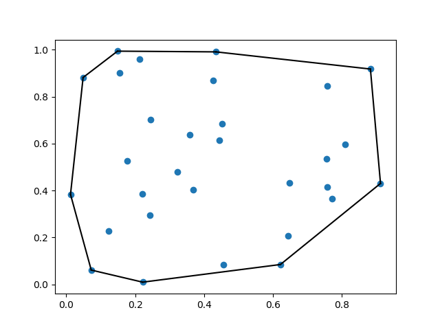

```python
from scipy.spatial import ConvexHull
import matplotlib.pyplot as plt

points = np.random.rand(30, 2)   # 30 random points in 2-D
hull = ConvexHull(points)

fig = plt.figure()
plt.plot(points[:,0], points[:,1], 'o')
for simplex in hull.simplices:
    plt.plot(points[simplex,0], points[simplex,1], 'k-');
```

## Signalverarbeitung ([scipy.signal](https://docs.scipy.org/doc/scipy/reference/tutorial/signal.html))

Linearen Trend aus einer Datenreihe entfernen mit `detrend`:

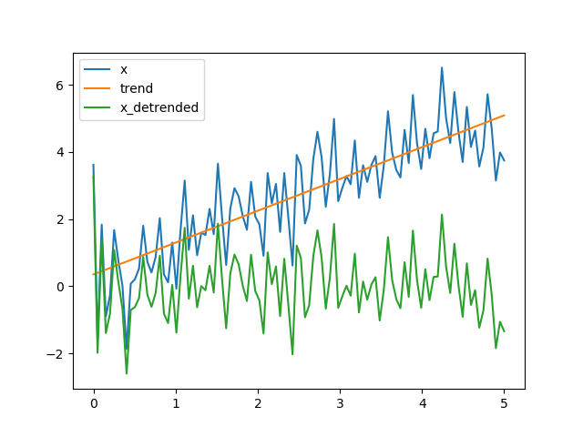

```python
import numpy as np
from scipy import signal
import matplotlib.pyplot as plt

t = np.linspace(0, 5, 100)
x = t + np.random.normal(size=100)

x_detrended = signal.detrend(x)

fig = plt.figure()
plt.plot(t, x, label="x")
plt.plot(t, x-x_detrended, label="trend")
plt.plot(t, x_detrended, label="x_detrended")
plt.legend(loc='best');
```

## Zusammenfassung

- SciPy ist eine Sammlung von mathematischen Algorithmen und Komfortfunktionen
- SciPy baut auf NumPy auf
- SciPy ist in Unterpakete für spezifische Bereiche organisiert
- Beschreibungen der Funktionen: siehe SciPy-Doku oder help-Befehl